# 資料視覺化

> 起步走

[數據交點](https://www.datainpoint.com) | 郭耀仁 https://linktr.ee/yaojenkuo

> The simple graph has brought more information to the data analyst’s mind than any other device.

> [John Tukey](https://en.wikipedia.org/wiki/John_Tukey)

```python
import numpy as np
import matplotlib.pyplot as plt
import pandas as pd
```

## 關於視覺化

## 什麼是視覺化

視覺化是致力於將抽象性概念具體化的學科，透過圖形中的大小、顏色或形狀等元素把原始資料、函數或方程式等所蘊含的特徵表達給瀏覽的人，進而將抽象的資訊轉換為溝通對象能快速掌握理解的精簡內容。

## 資料視覺化將資料值映射為 "Aesthetics"

常見的 "Aesthetics" 有

- 位置。
- 大小。
- 線條的寬度。
- 形狀。
- 顏色。
- 線條的樣式。

## 不同型態的資料值

- 數值：連續、浮點數。
- 數值：離散、整數、具有固定間隔的浮點數。
- 類別：無序或有序的因素、文字。
- 日期、時間、日期時間。

## 為何需要視覺化

## 抽象的原始資料：數列 $x$ 與 $f(x)$

```python
print(x)
print(fx)
```

```
[0.         0.12822827 0.25645654 0.38468481 0.51291309 0.64114136
 0.76936963 0.8975979  1.02582617 1.15405444 1.28228272 1.41051099
 1.53873926 1.66696753 1.7951958  1.92342407 2.05165235 2.17988062
 2.30810889 2.43633716 2.56456543 2.6927937  2.82102197 2.94925025
 3.07747852 3.20570679 3.33393506 3.46216333 3.5903916  3.71861988
 3.84684815 3.97507642 4.10330469 4.23153296 4.35976123 4.48798951
 4.61621778 4.74444605 4.87267432 5.00090259 5.12913086 5.25735913
 5.38558741 5.51381568 5.64204395 5.77027222 5.89850049 6.02672876
 6.15495704 6.28318531]
[ 0.00000000e+00  1.27877162e-01  2.53654584e-01  3.75267005e-01
  4.90717552e-01  5.98110530e-01  6.95682551e-01  7.81831482e-01
  8.55142763e-01  9.14412623e-01  9.58667853e-01  9.87181783e-01
  9.99486216e-01  9.95379113e-01  9.74927912e-01  9.38468422e-01
  8.86599306e-01  8.20172255e-01  7.40277997e-01  6.48228395e-01
  5.45534901e-01  4.33883739e-01  3.15108218e-01  1.91158629e-01
  6.40702200e-02 -6.40702200e-02 -1.91158629e-01 -3.15108218e-01
 -4.33883739e-01 -5.45534901e-01 -6.48228395e-01 -7.40277997e-01
 -8.20172255e-01 -8.86599306e-01 -9.38468422e-01 -9.74927912e-01
 -9.95379113e-01 -9.99486216e-01 -9.87181783e-01 -9.58667853e-01
 -9.14412623e-01 -8.55142763e-01 -7.81831482e-01 -6.95682551e-01
 -5.98110530e-01 -4.90717552e-01 -3.75267005e-01 -2.53654584e-01
 -1.27877162e-01 -2.44929360e-16]
```

## $f(x)=sin(x), \text{where } 0 \leq x \leq 2\pi$

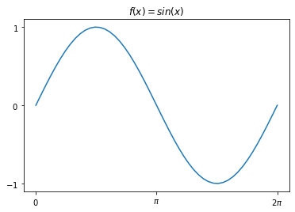

```python
plot_sinx(x, fx)
```

## 抽象的數學式

\begin{equation} S(x) = \frac{1}{1 + e^{-x}} \end{equation}

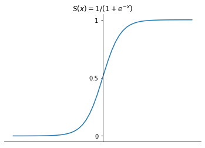

```python
plot_sigmoid(x, S)
```

## 視覺化在資料科學應用中佔有重要的地位

[figure not shown]

來源：[R for Data Science](https://r4ds.had.co.nz/)

## 資料科學家利用線圖描述損失函數（Loss functions）

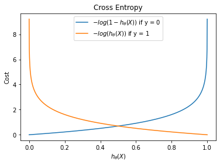

```python
plot_cross_entropy(x)
```

## 資料科學家利用表面圖描述梯度（Gradients）

[figure not shown]

來源：[Coursera | Machine Learning](https://www.coursera.org/learn/machine-learning)

## 資料科學家也利用等高線圖描述梯度

[figure not shown]

來源：[Coursera | Machine Learning](https://www.coursera.org/learn/machine-learning)

## 或者利用填滿等高線圖描述決策邊界（Decision boundary）

來源：https://scikit-learn.org/stable/auto_examples/ensemble/plot_voting_decision_regions.html#sphx-glr-auto-examples-ensemble-plot-voting-decision-regions-py

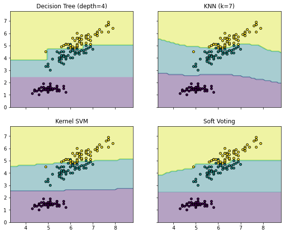

```python
plot_multiple_decision_boundary()
```

## 經典視覺化

1. [Minard's map of Napoleon's disastrous Russian campaign of 1812](https://en.wikipedia.org/wiki/Flow_map#/media/File:Minard.png)
2. [Hans Rosling's 200 Countries, 200 Years, 4 Minutes](https://youtu.be/jbkSRLYSojo)

## [Minard's map of Napoleon's disastrous Russian campaign of 1812](https://en.wikipedia.org/wiki/Flow_map#/media/File:Minard.png)

[figure not shown]

## [Hans Rosling's 200 Countries, 200 Years, 4 Minutes](https://youtu.be/jbkSRLYSojo)

[figure not shown]

## 更多關於 Hans Rosling 與 Gapminder

- https://www.gapminder.org/
- [Factfulness: Ten Reasons We’re Wrong About the World - and Why Things Are Better Than You Think](https://www.books.com.tw/products/F014082044)

## 好的視覺化特性

- 具有資訊價值。
- 能夠自我解釋。
- 可以重製。

## 資料科學應用的管線

## 視覺化被用於探索與溝通兩個場景

[figure not shown]

來源：[R for Data Science](https://r4ds.had.co.nz/)

## 載入、清理與轉換外型合稱為 "Wrangle"

[figure not shown]

Source: [R for Data Science](https://r4ds.had.co.nz/)

## 如何選擇資料視覺化的工具

- 能夠 "Wrangle" 資料。
- 能夠將資料值映射為 "Aesthetics"
- 能夠作為溝通的媒介。

## 瞭解資料科學從業者的偏好

- [2021 Kaggle ML & DS Survey](https://www.kaggle.com/c/kaggle-survey-2021)
- [Stack Overflow Trends](https://insights.stackoverflow.com/trends)

## 根據 [2021 Kaggle ML & DS Survey](https://www.kaggle.com/c/kaggle-survey-2021) 中的幾個問題

- What programming languages do you use on a regular basis? (Select all that apply)
- What programming language would you recommend an aspiring data scientist to learn first?
- What data visualization libraries or tools do you use on a regular basis? (Select all that apply)
- Which of the following business intelligence tools do you use most often?

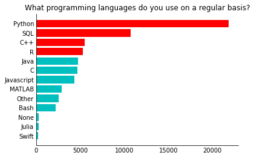

```python
ks.plot_survey_summary(question_index="Q7", n=4)
```

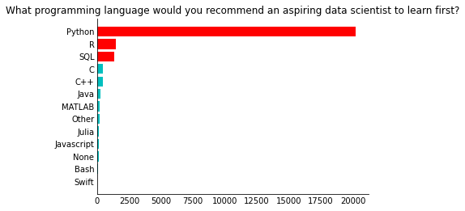

```python
ks.plot_survey_summary(question_index="Q8", n=3)
```

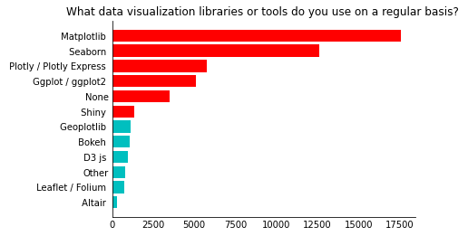

```python
ks.plot_survey_summary(question_index="Q14", n=6)
```

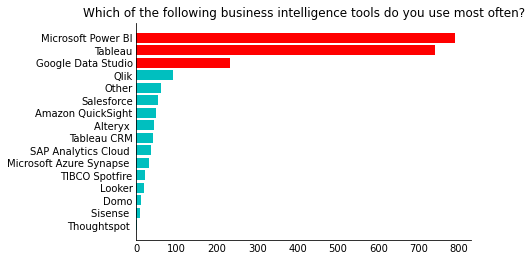

```python
ks.plot_survey_summary(question_index="Q35", n=3)
```

## 根據 [Stack Overflow Trends](https://insights.stackoverflow.com/trends) 的幾個趨勢

- [程式語言](https://insights.stackoverflow.com/trends?tags=r%2Cpython%2Csql%2Cmatlab%2Cjulia)
- [視覺化模組](https://insights.stackoverflow.com/trends?tags=matplotlib%2Cggplot2%2Cseaborn%2Cplotly%2Cshiny)

## 資料視覺化的工具選擇依據

- 使用人數的多寡。
- 使用彈性。
- 互動性。
- 可重製性。

## 混搭資料視覺化的工具

- Tableau/Power BI 應用於探索與溝通。
- SQL 應用於載入與清理。
- Python/R 應用於所有資料科學場景。

## 資料視覺化 123

1. 取得資料。
2. 清理轉換資料為合適的格式、外型。
3. 將資料映射為 "Aesthetics"

> When it comes to making graphs, half the battle occurs before you call any graphing commands.

> [Winston Chang](https://twitter.com/winston_chang?lang=en)

## 清理轉換資料為合適的格式、外型。

- 手動：MS Excel/Google Sheet
- 程式：Python/R
  - Python: [NumPy](https://numpy.org/)/[Pandas](https://pandas.pydata.org/)
  - R: [Tidyverse](https://www.tidyverse.org/)

## Tableau 起步走

## 從 Tableau 起步的幾個優點

- 跨平台（Windows/macOS）。
- No code/low code
- 校園計畫：https://www.tableau.com/community/academic
- Tableau 提供免費的 Public 版本。

## 什麼是 Tableau？

> Tableau 是視覺化分析平台，可以改變我們使用資料解決問題的方式，讓人員和組織能夠充分發揮資料的價值。

來源：https://www.tableau.com/

## （沒什麼用的）冷知識：Tableau 是古老的法文，意指鮮明生動的圖像

來源：https://www.vocabulary.com/dictionary/tableau

## 下載與安裝 Tableau

- Tableau Desktop Professional: https://www.tableau.com/products/desktop
- Tableau Desktop Public: https://public.tableau.com/en-us/s/download

## 分享 Tableau 視覺化的不同機制

- Tableau Desktop Professional vs. Tableau Online.
- Tableau Desktop Public vs. Tableau Public.

## 下載 Gapminder 資料

https://ntu-viz.s3.ap-northeast-1.amazonaws.com/gapminder/gapminder.csv

## 連結 `gapminder.csv`

Tableau Start page > Connect > To a File > Text file > `gapminder.csv`.

## 資料來源頁面

[figure not shown]

## 暸解資料型別

透過欄位上方的小圖示來暸解資料型別。

## Tableau 的主要資料型別

- 浮點數：Number(decimal)
- 整數：Number(whole)
- 日期時間：Date & Time
- 日期：Date
- 文字：String
- 布林：Boolean

## 篩選資料

假如不需要分析整個資料集，可以在資料來源就將資料進行篩選。

[figure not shown]

## 試著篩選一個文字欄位

[figure not shown]

## 試著篩選一個數值欄位

[figure not shown]

## 刪除所有篩選條件，完整資料的外型為 `(1704, 6)`。

[figure not shown]

## 工作表一覽

[figure not shown]

## 欄位類型

1. Dimensions: 類別型、離散型欄位。
2. Measures: 數值型、連續型欄位。

## （沒什麼用的）冷知識：Tableau 中的 Rows 是 Y 軸，Columns 是 X 軸

[figure not shown]

來源：https://media.giphy.com/media/xL7PDV9frcudO/giphy.gif

## 建立一個散佈圖（Scatter plot）

1. 將 `Life Exp` 拉到 Rows。
2. 將 `Gdp Percap` 拉到 Columns。

## Tableau 預設會對數值欄位使用 `SUM()` 函數

[figure not shown]

## 更改成維度

[figure not shown]

## 將 `Continent` 拉到 Color

[figure not shown]

## 將 `Pop` 拉到 Size

[figure not shown]

## 將 `Country` 拉到 Label

[figure not shown]

## 編輯軸為對數尺度（Log scale）

[figure not shown]

## 將 `Year` 拉到 Pages

完成，我們在 Tableau 重製了一個 [Hans Rosling's 200 Countries, 200 Years, 4 Minutes](https://youtu.be/jbkSRLYSojo) 視覺化！

## 上傳至 Tableau Public

- 在資料來源將 Connection 由 Live 調整為 Extract
- 在 Tableau Desktop Professional 將 Workbook 另存為 `.twbx`
- 在 Tableau Desktop Public 開啟 `.twbx`
- 分享至 Tableau Public